# İkiz Şehirler

Alkım Can Çelik

20.07.2019

## Önemli Çıkarımlar

- Şehirlerin elektrik tüketim davranışları bakımından 34 ikili eşleşme bulunmaktadır. Eşleşmelere ulaşmak için buraya tıklayabilirsiniz.
- Genel olarak sonuçlar beklentilerle uyuşmaktadır fakat Eskişehir-Manisa gibi birkaç sürpriz eşleşmeler de mevcuttur.
- Sanayide tüketilen elektriğin oranı profili belirlemede en önemli faktör olmuştur, çünkü şehirden şehre sanayinin gelişmişliği büyük değişkenlik göstermektedir.
- Nüfus elektrik tüketim profili belirlemede etkili olmuştur. Eğer şehirde sanayi veya tarımsal sulama sistemleri gelişmemişse, ilin nüfusu en temel faktör konumuna gelmektedir.
- Şehrin konumu ve iklimi elektrik tüketim profili belirlemede büyük rol oynar fakat en temel faktörler değildir. Beşeri unsurlar, doğal unsurların önüne geçebilmektedir.

## Giriş

Bu rapor, şehirlerin elektrik tüketim profillerini çıkarmak ve hangi şehirlerin elektrik tüketimi bakımından birbirlerine benzediğini bulmak için hazırlanmıştır. Ocak 2017’den Nisan 2019’a kadar olan 81 ilin aylık faturalanan elektrik tüketim miktarları veri seti olarak kullanılmıştır. Bu veri seti EPDK(Enerji Piyasası Düzenleme Kurumu)’dan alınmıştır.

Tüketim profili belirleme, 4 unsur etrafında şekillenecektir. Bunlar; sanayide elektrik tüketimi, meskenlerde elektrik tüketimi, işletmelerde elektrik tüketimi ve tarımsal sulamada elektrik tüketimi. Az sayıda unsur olmasından dolayı grup sayısı 7 ile sınırlı tutulmuştur.

## Hazırlık

Ocak 2017’den Nisan 2019’a, EPDK’dan aylık sektör raporları incelendi ve aylık faturalanan elektrik miktarı referans olarak alındı. Aylık zaman aralığındaki her tablo, tek bir tabloda birleştirildi. Tabloya bu [linkten](http://alkimcelik.github.io/Monthly_Cities_Electricity_Consumptions.rds) ulaşabilirsiniz.

Büyükşehirler, yukarıda sayılan unsurların her birinde miktar olarak yüksek değerlere sahip olduğundan tüm şehirler için, her bir unsurun şehir içi birbirlerine göre yüzdelik oranı baz alınmıştır. Farklı yılların aynı aylarında elektrik tüketim oranları birbirlerine çok yakın olduğundan ve raporun ilerleyen kısımlarında bahsedilecek olan gruplama işleminde, şehrin yıldan yıla aynı aylar için farklılaşan değerlerinden dolayı farklı gruba düşeceğini engellemek için bu ayların ortalaması alınmıştır.

Yukarıdaki işlemden sonra, şehirleri gruplamak için farklı yöntemler kullanıldı. Farklı yöntemler olmasının nedeni, sonucun kesinliğini arttırmaktır. Sonuçlar 81 satır ve 81 sütundan oluşan bir benzerlik matrisine aktarıldı. Her bir gruplama yöntemi için, şehirler aynı grupta olduğunda şehirlerin satır ve sütun olarak eşleştiği hücrelerdeki değerler 1 arttırıldı. Sonuç olarak; 6 gruplama yöntemi uygulandığından, matriste değeri 6 olan hücreye denk gelen sütun ve satırlardaki şehirler, en yakın şehirler olarak eşleştirildi.

Son olarak, k-means algoritması ile oluşturulan şehir grupları, elektrik tüketim profillerine göre sınıflandırıldı.

## Şehir Grupları

Bu bölümde, hiyerarşi metodu ile gruplanan şehirler incelenecektir. Şehirlerin ilişkisi ve grupları aşağıdaki şemada gösterilmektedir. Aynı gruptaki şehirler aynı renkte gösterilmektedir.

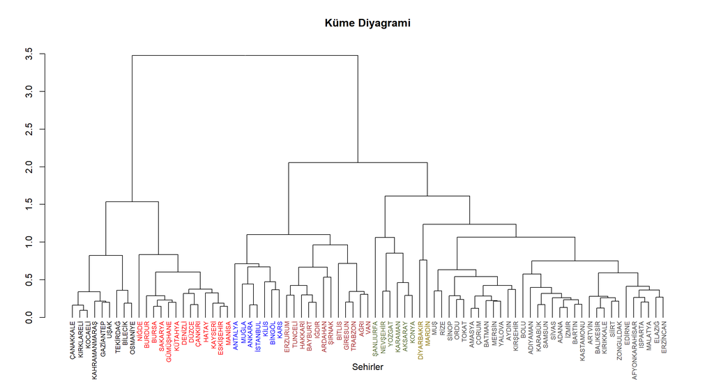

Bazı sürpriz sonuçlar olmasına rağmen, şehirler mantıklı bir şekilde gruplandırılmış denebilir. Şehirleri bağlayan dalların uzunluğu, şehirlerin elektrik tüketimlerindeki benzerliği sembolize eder. Dalın uzunluğu kısaldıkça aralarındaki benzerlik artar. Örnek olarak, yukarıdaki şemayı incelersek, Çorum’u ve Amasya’yı birbirine bağlayan dalın yüksekliği çok kısa olduğu için elektrik tüketim profilleri birbirine çok benzer denebilir. Kırklareli ile Kocaeli’nin de çok yakın bir ilişkiye sahip olduğu açıkça fark edilebilir. İstanbul ile Kilis incelendiğinde birbirleriyle yukarıdaki örnekler kadar yakın olmadığını, fakat ilginç bir şekilde, birbirleriyle çok alakasız da olmadıkları çıkarımında bulunulabilir. İstanbul’un oransal olarak dengeli bir elektrik tüketimine sahip olduğundan Kilis’e elektrik tüketim profili olarak biraz benziyor.

İklim elektrik tüketim profili belirlemede önemli bir unsurdur. Aynı grupta olan şehirler genellikle aynı iklim koşullarına sahiptir. Diyarbakır ve Mardin buna iyi bir örnektir. Fakat grafikten de anlaşılacağı üzere, en önemli unsur değildir. Aynı kümede olup iklim koşulları çok farklı olan şehirler de bulunaktadır. Antalya ile Kars’ın aynı grupta olması buna güzel bir örnektir. Aynı şekilde, aynı iklim koşullarına sahip olup farklı gruplarda bulunan şehirler de vardır. Antalya ve Mersin bu duruma bir örnektir. Bunun sebebi, iklimden etkilenmeyen ekonomik aktivitelerdir. Sanayi tabanlı aktiviteler, gruplama sürecinde çok önemli bir faktördür, önemi aşağıda detaylı bir şekilde açıklanmıştır.

## Grupların Sınıflandırılması

Bu bölümde, k-means algoritması ile oluşturulan gruplar sınıflandırılacaktır.

Sınıflandırılacak şehirlerin ay ay sınıflandırılması yeterli ve anlaşılır sonuçlar gösteremeyeceği için aynı mevsimdeki ayların ortalaması alınarak, yani zaman aralığı olarak mevsimler baz alınarak sınıflandırma yapılmıştır.

Düğümler, sektör aktivitelerini ve zamanını temsil eder. Köklerdeki kutucukların tepesindeki sayı, düğümlerdeki koşulları en iyi karşılayan grubun numarasını ifade eder. Bu numaraların altındaki yüzdeler de bu koşulları sağlayan şehirlerin gruplara dağılımını gösterir. Örnek olarak; kahverengi kutucuk için bakacak olursak, kutucuğa ulaşan koşulları karşılayan şehirlerin %80’i 3. Gruptadır, kalan %20’si ise 4. Gruptadır. Karar şeması aşağıda bulunmaktadır.

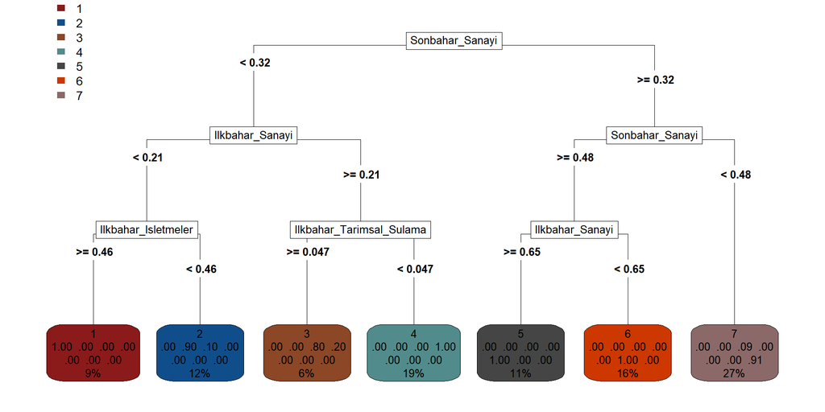

Sanayide tüketilen elektriğin oranı, sınıflandırma yapılırken en önemli unsur olarak gözükmektedir. Sonbaharda sanayide tüketilen elektriğin yüzde 32 oranından az ya da fazla olması, sınıflandırmada en ayrıştırıcı detay olarak anlaşılıyor. Şemanın tümüne bakıldığında, sanayideki elektrik tüketimi oranı grupların sınıflarını belirliyor. Çünkü sanayi aktivitelerinin miktarı şehirden şehire büyük farklılıklar göstermektedir.

Gruplar, aşağıdaki Türkiye haritasında gösterilmiştir.

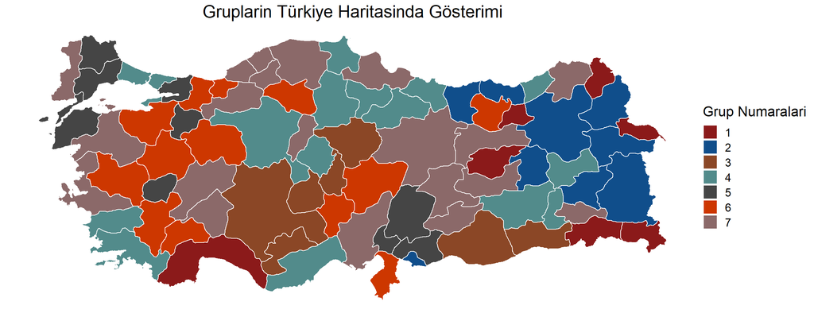

Yukarıdaki haritaya bakıldığında, belli bir spesifik karaktere sahip olan gruplardaki şehirlerin, genellikle birbirine konum olarak yakın olduğu kolaylıkla anlaşılabilir. Özellikle Doğu Anadolu bölgesinde, sanayinin gelişmemiş olmasından dolayı bu sonuç daha barizdir.

Ek olarak, tarımsal sulama sistemlerinin yaygın olduğu şehirler de konum olarak birbirine yakındır ve bu şehirlerde karasal iklim hakimdir. Bu durumun sebebi o bölgedeki kuraklıktır.

Spesifik karaktere sahip olan gruplar aşağıda detaylı olarak açıklanmıştır.

### 1) Grup 5 (Sanayi)

```
##        Sehirler grup_numarasi
## 1       BILECIK             5
## 2     GAZIANTEP             5
## 3 KAHRAMANMARAS             5
## 4    KIRKLARELI             5
## 5       KOCAELI             5
## 6      OSMANIYE             5
## 7      TEKIRDAG             5
## 8          USAK             5
## 9     ÇANAKKALE             5
```

Sanayideki elektrik tüketimi oransal olarak en yüksek bu şehirlere aittir. Gruplandırmak için az sayıda unsurun olması ve grup sayısının az olmasından dolayı Çanakkale ve Bilecik gibi sürpriz sonuçlar mevcuttur. Başka bir sebep ise sanayi dışında yukarıda bahsedilen unsurların, sanayi ile karşılaştırıldığında zayıf kalması, başka bir deyişle, sınıflandırma sürecinde etkin rol oynayamamaları olabilir. Sanayide tüketilen elektriğin çalışan sayısına oranı, diğer unsurlarda tüketilen elektrik miktarının çalışan sayısına oranından çok yüksektir.

Sürpriz sonuçların başka bir sebebi de bu şehirlerin nüfusu olabilir. Bu gruptaki sürpriz sonuçlu şehirlerin nüfusu, ülkedeki çoğu şehirden daha düşüktür. Bu şehirlerde az sayıda fabrika olmasının, elektrik tüketimi üzerinde büyük etkiler yaratacağı su götürmez bir gerçektir. Bir fabrikanın açılması bile, bu küçük şehirlerde, sanayideki elektrik tüketimini oransal olarak kolaylıkla arttırabilir.

### 2) Grup 3 (Tarım)

```
##    Sehirler grup_numarasi
## 1   AKSARAY             3
## 2   KARAMAN             3
## 3     KONYA             3
## 4    MARDIN             3
## 5  NEVSEHIR             3
## 6    YOZGAT             3
## 7 SANLIURFA             3
```

Yukarıdaki karar şemasından anlaşılacağı üzere, tarımsal sulamada tüketilen elektrik oransal olarak en yüksek grup 3’e aittir. Yukarıdaki şehirler bu grubun üyeleridir. Yozgat dışında sürpriz bir sonuç yoktur. İlginç bir şekilde Yozgat karar şemasındaki 3. gruba ait tüm koşulları sağlamaktadır. Detaylı araştırmalar sonucu, Yozgat’ta sanayiye dayalı bir tüketimin olmadığı ve ekonomik faaliyet olarak tarımın büyük bir pay sahibi olduğu sonucuna varılıyor.

Veri seti incelendiğinde, Diyarbakır’ın da koşulları karşıladığı anlaşılıyor. Fakat diğer tüketim unsurlarından dolayı 4. gruptadır.

Bu gruptaki şehirler birçok ortak paydada buluşuyor. Ekonomik aktiviteleri ve iklim koşulları bakımından birbirleriyle çok benzerdir. Bu gruptaki tüm şehirlerde karasal iklim hakimdir. Kuraklık, bu şehirlerde ortak problemdir. Bu şehirlerde tarıma ve sulama sistemlerine yüklü yatırımlar vardır.

Sınıflandırmada en temel faktör olan sanayideki elektrik tüketimi, bu şehirlerde oransal olarak düşüktür. Bundan dolayı tarımsal sulamada tüketilen elektrik oransal olarak yüksektir.

### 3) Grup 1 (İşletmeler)

```
##   Sehirler grup_numarasi
## 1  ANTALYA             1
## 2  ARDAHAN             1
## 3  BAYBURT             1
## 4  HAKKARI             1
## 5    IGDIR             1
## 6  TUNCELI             1
## 7   SIRNAK             1
```

Bu gruptaki şehirler sanayide ve tarımsal sulama sistemlerinde gelişmemiştir. Antalya hariç bu şehirler, elektrik tüketimi gerektirecek spesifik bir alanda uzmanlaşmamıştır. Antalya’da turizm önemli bir rol oynamaktadır. Turizmdeki elektrik tüketimi, işletmelerde tüketilen elektriğe dahil edilmiştir.

Bu şehirlerin nüfuslarına bakıldığında, Antalya hariç hepsinin nüfusu çok düşüktür. Kötü iklim şartları, kurak topraklar, ulaşımda zorluklar gibi sebeplerden dolayı bu şehirlerin ülke ekonomisine katkısı azdır. Üretici bir şehirden çok tüketici konumundadırlar.

Sonuç olarak, işletmelerde tüketilen elektrik oranı en yüksek bu şehirlere aittir.

### 4) Grup 2 (Mesken)

```
##   Sehirler grup_numarasi
## 1     AGRI             2
## 2   BINGÖL             2
## 3   BITLIS             2
## 4  ERZURUM             2
## 5  GIRESUN             2
## 6     KARS             2
## 7    KILIS             2
## 8  TRABZON             2
## 9      VAN             2
```

Bu gruptaki şehirlerde 1. gruba benzer şekilde, ne sulama sistemlerinde ne de sanayide gelişmiştir. Fakat, 1. gruptan önemli bir noktada ayrılır, o da nüfustur. Bu gruptaki şehirlerin nüfusları genel olarak 1. gruptaki şehirlerden fazladır. Bu yüzden, meskenlerde tüketilen elektriğin oranı 1. gruptan yüksektir.

Bu şehirlerin iklim koşulları incelendiğinde bu şehirlerin ortalama hava sıcaklığının düşük olduğu kolaylıkla fark edilebilir. Hem soğuk hava şartları hem de nüfusun fazla olmasından dolayı meskenlerde tüketilen elektrik oranı diğer gruplara göre daha yüksektir.

Veriler incelendiğinde, 1. gruptaki ile 2. gruptaki şehirlerin elektrik tüketimlerinin oransal olarak birbirlerine çok benzer olduğu anlaşılır. Sebebi, bu iki şehirde de sanayi ve tarımsal sulama sistemleri gelişmemiştir. Ek olarak, işletmelerde tüketilen elektriğin oranı ile meskenlerde tüketilen elektriğin oranı birbirleri ile parallelik gösterir. Bu yüzden, alt bölümdeki bazı ikili şehir eşleşmelerinde şehirlerden biri 1. gruba, diğeri de 2. gruba aittir. Ek olarak, bu gruptaki çoğu şehirler, 1. gruptaki gibi Doğu Anadolu Bölgesi’nde yer almaktadır.

## İkili Şehir Eşleşmeleri

```
##  [1] "AGRI-BAYBURT"            "AGRI-ERZURUM"
##  [3] "BAYBURT-ERZURUM"         "ELAZIG-ERZINCAN"
##  [5] "BURSA-GÜMÜSHANE"         "HAKKARI-IGDIR"
##  [7] "DENIZLI-KAYSERI"         "BILECIK-KIRKLARELI"
##  [9] "BILECIK-KOCAELI"         "KIRKLARELI-KOCAELI"
## [11] "KARAMAN-KONYA"           "ESKISEHIR-MANISA"
## [13] "BILECIK-OSMANIYE"        "KIRKLARELI-OSMANIYE"
## [15] "KOCAELI-OSMANIYE"        "MUS-RIZE"
## [17] "BURSA-SAKARYA"           "GÜMÜSHANE-SAKARYA"
## [19] "ARTVIN-SIIRT"            "BILECIK-TEKIRDAG"
## [21] "KIRKLARELI-TEKIRDAG"     "KOCAELI-TEKIRDAG"
## [23] "OSMANIYE-TEKIRDAG"       "MUS-TOKAT"
## [25] "RIZE-TOKAT"              "ARDAHAN-TUNCELI"
## [27] "KAHRAMANMARAS-USAK"      "TRABZON-VAN"
## [29] "KIRIKKALE-YALOVA"        "KAHRAMANMARAS-ÇANAKKALE"
## [31] "USAK-ÇANAKKALE"          "DÜZCE-ÇANKIRI"
## [33] "AMASYA-ÇORUM"            "ADANA-IZMIR"
```

Hazırlık bölümünde ifade edildiği gibi eşleşmeler, benzerlik matrisi oluşturularak belirlenmiştir. 6 gruplama yöntemi kullanıldığından matriste değeri 6 olan hücrelere denk gelen, bir başka deyişle, her gruplama metodunda aynı gruba düşen şehirler yukarıda ifade edilmiştir.

Eşleşmeler incelendiğinde, eşleşen şehirlerin ekonomik faaliyetlerinin birbiriyle benzerlik gösterdiği açıkça görülüyor. Sanayi aktiviteleri olarak Kocaeli-Tekirdağ, Kahramanmaraş-Uşak, Bilecik-Osmaniye; tarımsal aktiviteler olarak Karaman-Konya; meskenlerde ve işletmelerde tüketilen elektriğe göre Hakkari-Iğdır, Ağrı-Bayburt, Trabzon-Van, Ardahan-Tunceli eşleşmeleri bu duruma kanıtlardır.

Genel olarak, beklendiği üzere, ikili şehirler ya iklim koşulları olarak, ya nüfus olarak ya da bu iki faktörde de birbirlerine çok yakındır. Bu yüzden, ekonomik aktiviteleri ve elektrik tüketim profilleri birbirlerine çok benzerdir.

İkili eşleşmeler arasında bazı beklenmedik sonuçlar da yok değil. Eskişehir-Manisa eşleşmesi buna örnektir. Araştırmalar sonucu, bu iki şehirde sanayiye son zamanlarda yoğun bir teşvik olduğu anlaşılıyor. Sanayideki elektrik tüketiminin profil belirlemedeki önemi bu noktada bir kez daha anlaşılıyor. Artvin-Siirt eşleşmesi de ilginç eşleşmelerden bir tanesi. Bu şehirlerin hem sanayisi gelişmemiş hem de nüfusları çok düşüktür. Bu yüzden elektrik tüketim profilleri birbirlerine çok benzerdir.

## Kaynakça

https://www.epdk.org.tr/Detay/Icerik/3-0-23/elektrikaylik-sektor-raporlar

https://rpubs.com/sercandogan/turkeymap

http://www.eskisehir.bel.tr/sayfalar.php?sayfalar_id=15

https://www.egitimsistem.com/manisanin-ekonomik-faaliyetleri-nelerdir-65002h.htm

https://www.turkcebilgi.com/artvin_ekonomisi

http://siirt.bel.tr/tr-tr/alt-sayfalar/198/ekonomi

http://www.cografya.gen.tr/tr/yozgat/ekonomi.html

## Yazar Hakkında

Alkım Can Çelik şu anda Algopoly şirketinde veri bilimi ve analizi üzerine staj yapmaktadır. Elektrik dağıtım şirketlerinin tahmin performanslarını ve şehirlerin elektrik tüketimlerini incelemektedir. Ayrıca EPİAŞ’ta Gün Önce Piyasası’ndaki Piyasa Takas Fiyatı üzerine çalışmalarda bulunmuştur. Boğaziçi Üniversitesi Endüstri Mühendisliği’nde 3. sınıf öğrencisidir. Veri bilimi ve analizi, yöneylem araştırması, uygulamalı makine öğrenmesi algoritmaları ve finans alanlarına ilgilidir.

Diğer raporlara yazarın [sitesi](https://alkimcelik.github.io/) üzerinden ulaşabilirsiniz. İletişime geçmek için alkimcancelik33@gmail.com adresine mail atabilir ya da [Linkedin](https://www.linkedin.com/in/alkimcelik-b8446b131/) üzerinden bağlantı kurabilirsiniz.